# Chapter 2 - Data Visualization with ggplot2

```r
library(tidyverse)
```

| manufacturer | model | displ | year | cyl | trans | drv | cty | hwy | fl | class |
| --- | --- | --- | --- | --- | --- | --- | --- | --- | --- | --- |
| audi | a4 | 1.8 | 1999 | 4 | auto(l5) | f | 18 | 29 | p | compact |
| audi | a4 | 1.8 | 1999 | 4 | manual(m5) | f | 21 | 29 | p | compact |
| audi | a4 | 2.0 | 2008 | 4 | manual(m6) | f | 20 | 31 | p | compact |
| audi | a4 | 2.0 | 2008 | 4 | auto(av) | f | 21 | 30 | p | compact |
| audi | a4 | 2.8 | 1999 | 6 | auto(l5) | f | 16 | 26 | p | compact |
| audi | a4 | 2.8 | 1999 | 6 | manual(m5) | f | 18 | 26 | p | compact |
| audi | a4 | 3.1 | 2008 | 6 | auto(av) | f | 18 | 27 | p | compact |
| audi | a4 quattro | 1.8 | 1999 | 4 | manual(m5) | 4 | 18 | 26 | p | compact |
| audi | a4 quattro | 1.8 | 1999 | 4 | auto(l5) | 4 | 16 | 25 | p | compact |
| audi | a4 quattro | 2.0 | 2008 | 4 | manual(m6) | 4 | 20 | 28 | p | compact |

[output cut: 224 more lines]

Create a plot of a car’s engine siza (displ) and its fuel efficiency (hwy). I’m going to be using the pipe operator %ª% because it improves readability even tough it is introduced in later chapters.

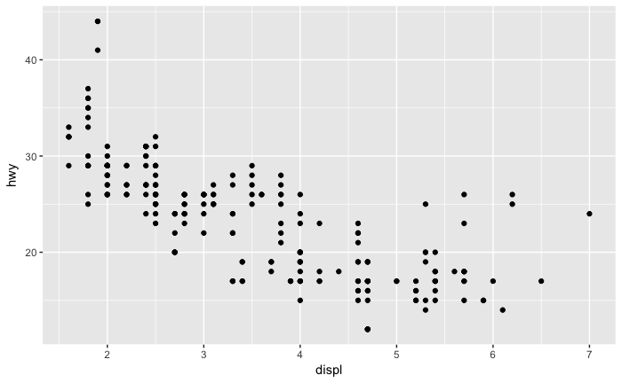

ggplot create a coordinate system. You can add layers to get exactly the graphic you want. Ggplot when run without any additional code creates a blank rectangle.

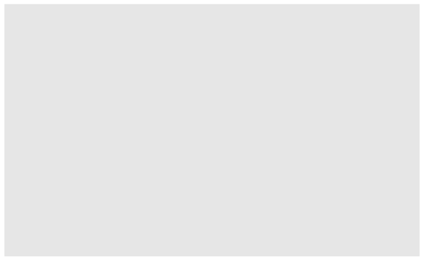

```r
ggplot()
```

*geom_point* creates a scatterplot *mapping* is used to tell ggplot how to graph/visualize the variables you are interested in. It always goes in had with *aes*. For a scatterplot you must indicate within *aes* the x and y variables within the data.

## Graphing Template

ggplot(data = ) + (mapping = aes())

Using the pipe operator

%>% ggplot() + (mapping = aes())

Exercises

Run ggplot(data = mpg). What do you see?

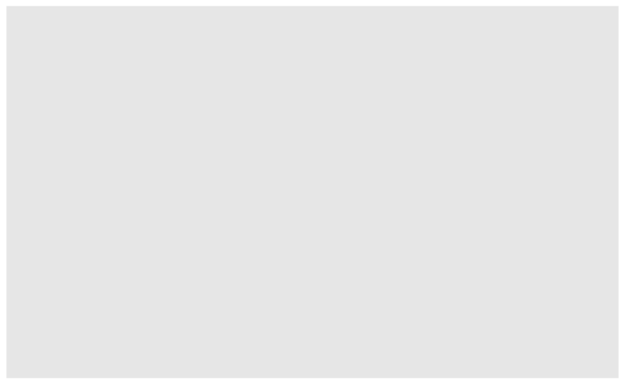

How many rows are in mpg? How many columns?

```r
dim(mpg)
```

```
[1] 234  11
```

What does the drv variable describe? Read the help for ?mpg to find out. f = front-wheel drive, r = rear wheel drive, 4 = 4wd

Make a scatterplot of hwy vs cyl.

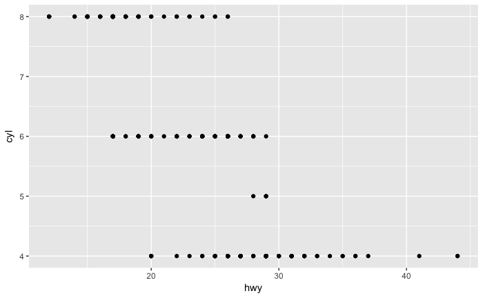

```r
mpg %>%
  ggplot() +
  geom_point(mapping = aes(x = hwy, y = cyl))
```

What happens if you make a scatterplot of class vs drv? Why is the plot not useful? It’s not usefull because they are both categorical variables.

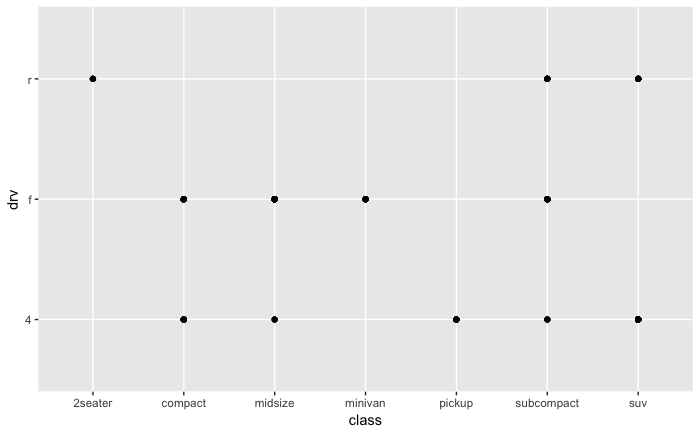

Asthetic mappings An aesthetic is a visual property of the objects in your plot. Asthetics include the shape, color or sizes of the shapes in the plot. When talking about asthetics, we talk about levels instead of values.

You can assign diferent levels to a variable in the data.

Here you can see the mapping of colors. You can map the colors of your points to variables in the data

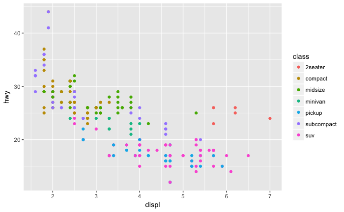

Here you can see the mapping of sizes to the class variable

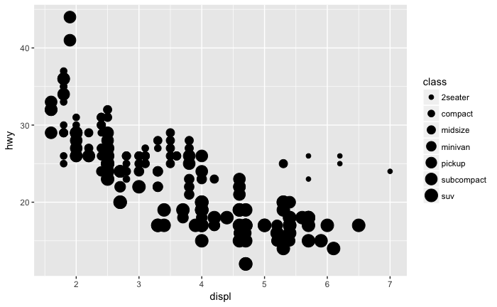

alpha controls the transparency

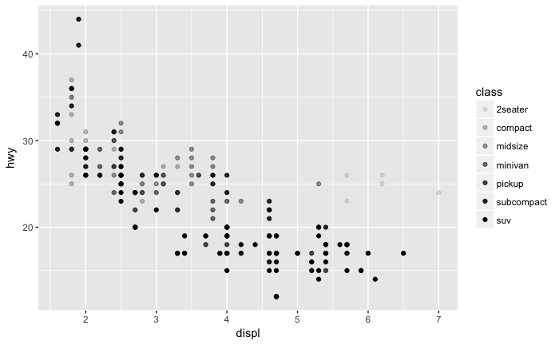

shape of the points

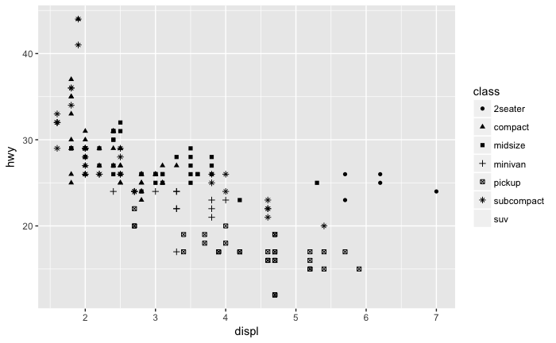

x and y are asthetics. Visual properties that you can map to variables to display information about the data In my own words, just like class can make color appear depending on the variable assigned, so can x and y make a plot appear by graphing it in the cartesian plane.

Ggplot automates a lot of things after you map it to a variable. For x-y points, it creates an axis line, with color, size, shape it creates a legend.

You can also set asthetic properties manually

This failed because I put the manual asthetic property inside the function *aes* instead of outside.

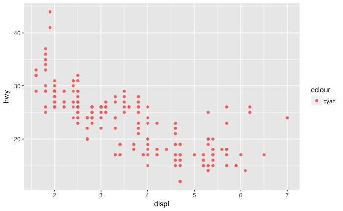

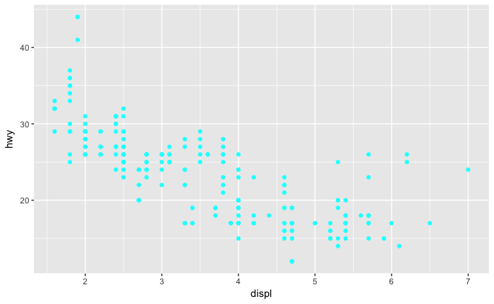

```r
mpg %>%
  ggplot() +
  geom_point(mapping = aes(x = displ, y = hwy), color = "cyan")
```

Review Questions

1. What’s gone wrong with this code? Why are the points not blue? ggplot(data = mpg) + geom_point( mapping = aes(x = displ, y = hwy, color = “blue”) )

The manual color blue was called inside the function aes.

2. Which variables in mpg are categorical? Which variables are continuous? (Hint: type ?mpg to read the documentation for the dataset.) How can you see this information when you run mpg?

categorical: model name, year, cyl, trans, drv, fl, class continuous: displ, cty, hwy

3. Map a continuous variable to color, size, and shape. How do these aesthetics behave differently for categorical versus contin‐ uous variables?

Color generates a color scale instead of a legend with discreet colors

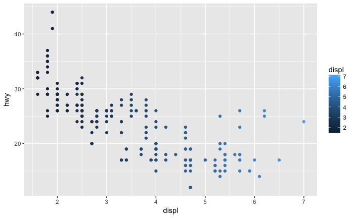

```r
mpg %>%
  ggplot() +
  geom_point(mapping = aes(x = displ, y = hwy, color = displ))
```

Size the circles get increase in size as the variable increases

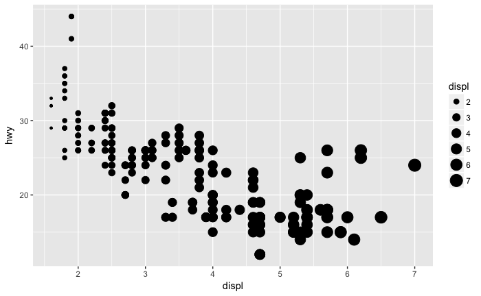

Shape can’t be mapped to a continous variable

```r
mpg %>%
  ggplot() +
  geom_point(mapping = aes(x = displ, y = hwy, shape = displ))
```

```
Error: A continuous variable can not be mapped to shape
```

4. What happens if you map the same variable to multiple aesthet‐ ics?
5. What does the stroke aesthetic do? What shapes does it work with? (Hint: use ?geom_point.)